# Vectors and matrices

In vectors we introduced the concept of a vector. A vector mathematically is a geometric object with two attributes a magnitude and a direction. (The direction is undefined in the case the magnitude is $0$.) Vectors are typically visualized with an arrow, where the anchoring of the arrow is context dependent and is not particular to a given vector.

Vectors and points are related, but distinct. Let's focus on 3 dimensions. Mathematically, the notation for a point is $p=(x,y,z)$ while the notation for a vector is $\vec{v} = \langle x, y, z \rangle$. The $i$th component in a vector is referenced by a subscript: $v_i$. With this, we may write a typical vector as $\vec{v} = \langle v_1, v_2, \dots, v_n \rangle$ and a vector in $n=3$ as $\vec{v} =\langle v_1, v_2, v_3 \rangle$. The different grouping notation distinguishes the two objects. As another example, the notation $\{x, y, z\}$ indicates a set. Vectors and points may be *identified* by anchoring the vector at the origin. Set's are quite different from both, as the order of their entries is not unique.

In `Julia`, the notation to define a point and a vector would be identical, using square brackets to group like-type values: `[x, y, z]`. The notation `(x,y,z)` would form a [tuple](https://en.wikipedia.org/wiki/Euclidean_vector) which though similar in many respects, tuples do not have the operations associated with a point or a vector defined for them.

The square bracket constructor has some subtleties:

- `[x,y,z]` calls `vect` and creates a 1-dimensional array
- `[x; y; z]` calls `vcat` to **v**ertically con**cat**enate values together. With simple numbers the two are identical, but not in other cases. (For example, is `A` is a matrix then `[A,A]` is a vector of matrices, `[A;A]` is a matrix combined from the two pieces.
- `[x y z]` calls `hcat` to **h**orizontally con**cat**enate values together. If `x`, `y` are numbers then `[x y]` is *not* a vector, but rather a 2D array with a single row and two columns.
- finally `[w x; y z]` calls `hvcat` to horizontally and vertically concatenate values together to create a container in two dimensions, like a matrix.

(A vector, mathematically, is a one-dimensional collection of numbers, a matrix a two-dimensional *rectangular* collection of numbers, and an array an $n$-dimensional rectangular-like collection of numbers. In `Julia`, a vector can hold a collection of objects of arbitrary type, though generally all of the same type.)

## Vector addition, scalar multiplication

As seen earlier, vectors have some arithmetic operations defined for them. As a typical use of vectors, mathematically, is to collect the $x$, $y$, and $z$ (in 3D) components together, operations like addition and subtraction operate component wise. With this, addition can be visualized geometrically: put the tail of $\vec{v}$ at the tip of $\vec{u}$ and draw a vector from the tail of $\vec{u}$ to the tip of $\vec{v}$ and you have $\vec{u}+\vec{v}$. This is identical by $\vec{v} + \vec{u}$ as vector addition is commutative. Unless $\vec{u}$ and $\vec{v}$ are parallel or one has $0$ length, the addition will create a vector with a different direction from the two.

Another operation for vectors is *scalar* multiplication. Geometrically this changes the magnitude, but not the direction of a vector, when the *scalar* is positive. Scalar multiplication is defined component wise, like addition so the $i$th component of $c \vec{v}$ is $c$ times the $i$th component of $\vec{v}$. When the scalar is negative, the direction is "reversed."

To illustrate we define two 3D vectors:

```julia
u, v = [1, 2, 3], [4, 3, 2]
```

```
([1, 2, 3], [4, 3, 2])
```

The sum is component-wise summation (`1+4, 2+3, 3+2`):

```julia
u + v
```

```
3-element Array{Int64,1}:
 5
 5
 5
```

For addition, as the components must pair off, the two vectors being added must be the same dimension.

Scalar multiplication by `2`, say, multiplies each entry by `2`:

```julia
2 * u
```

```
3-element Array{Int64,1}:
 2
 4
 6
```

## The length and direction of a vector

If a vector $\vec{v} = \langle v_1, v_2, \dots, v_n\rangle$ then the *norm* (also Euclidean norm or length) of $\vec{v}$ is defined by:

$$~ \| \vec{v} \| = \sqrt{ v_1^2 + v_2^2 + \cdots + v_n^2}. ~$$

The definition of a norm leads to a few properties. First, if $c$ is a scalar, $\| c\vec{v} \| = |c| \| \vec{v} \|$–which say scalar multiplication by $c$ changes the length by $|c|$. (Sometimes, scalar multiplication is described as "scaling by....") The other property is an analog of the triangle inequality, in which for any two vectors $\| \vec{v} + \vec{w} \| \leq \| \vec{v} \| + \| \vec{w} \|$. The right hand side is equal only when the two vectors are parallel and addition is viewed as laying them end to end.

A vector with length $1$ is called a *unit* vector. Dividing a non-zero vector by its norm will yield a unit vector, a consequence of the first property above. Unit vectors are often written with a "hat:" $\hat{v}$.

The direction indicated by $\vec{v}$ can be visualized as an angle in 2 or 3 dimensions, but in higher dimensions, visualization is harder. For 2-dimensions, we might associate with a vector, it's unit vector. This in turn may be identified with a point on the unit circle, which from basic trigonometry can be associated with an angle. Something similar, can be done in 3 dimensions, using two angles. However, the "direction" of a vector is best thought of in terms of its associated unit vector. With this, we have a decomposition of a vector $\vec{v}$ into a magnitude scalar and a direction when we write $\vec{v} = \|\vec{v}\| \cdot (\vec{v} / \|\vec{v}\|)=\|\vec{v}\| \hat{v}$.

## Visualization of vectors

Vectors may be visualized in 2 or 3 dimensions using `Plots`. In 2 dimensions, the `quiver` function may be used. To graph a vector, it must have its tail placed at a point, so two values are needed.

To plot `u=[1,2]` from `p=[0,0]` we have the following usage:

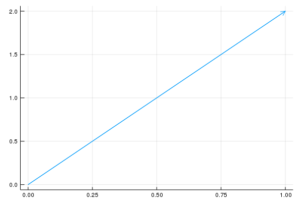

```julia
using Plots
gr()       # better arrows than plotly()
quiver([0],[0], quiver=([1],[2]))
```

The cumbersome syntax is typical here. We naturally describe vectors and points using `[a,b,c]` to combine them, but the plotting functions want to plot many such at a time and expect vectors containing just the `x` values, just the `y` values, etc. The above usage looks a bit odd, as these vectors of `x` and `y` values have only one entry. Converting from the one representation to the other requires reshaping the data, which we will do with the following function:

```julia
unzip(vs) = Tuple(eltype(first(vs))[xyz[j] for xyz in vs] for j in eachindex(first(vs)))
```

```
unzip (generic function with 1 method)
```

This takes a vector of vectors, and returns a tuple containing the `x` values, the `y` values, etc. So if `u=[1,2,3]`, the `unzip([u])` becomes `([1],[2],[3])`. And if `v=[4,5,6]`, then `unzip([u,v])` becomes `([1,4],[2,5],[3,6])`, etc. (The `zip` function in base does essentially the reverse operation.)

With `unzip` defined, we can plot a 2-D vector `v` anchored at point `p` through `quiver(unzip([p])..., quiver=unzip([v]))`.

To illustrate, the following defines 3 vectors (the third through addition), then graphs all three, though in different starting points to emphasize the geometric interpretation of vector addition.

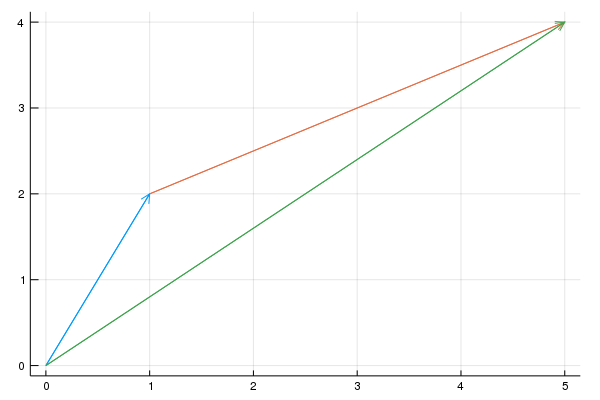

```julia
u = [1, 2]
v = [4, 2]
w = u + v
p = [0,0]
quiver(unzip([p])..., quiver=unzip([u]))
quiver!(unzip([u])..., quiver=unzip([v]))
quiver!(unzip([p])..., quiver=unzip([w]))
```

Plotting a 3-d vector is not supported in all toolkits with `quiver`. A line segment may be substituted and can be produced with `plot(unzip([p,p+v])...)`. To avoid all these details, we will utilize the following function to *add* a vector to an existing plot. The function requires a point, `p`, and the vector, `v`:

```julia
function arrow!(plt::Plots.Plot, p, v; kwargs...)
  length(p) == 2 && return quiver!(plt, unzip([p])..., quiver=unzip([v]); kwargs...)
  length(p) == 3 && return plot!(plt, unzip([p, p+v])...; kwargs...)
end
arrow!(p,v;kwargs...) = arrow!(Plots.current(), p, v; kwargs...)
```

```
arrow! (generic function with 2 methods)
```

With this, the above simplifies to:

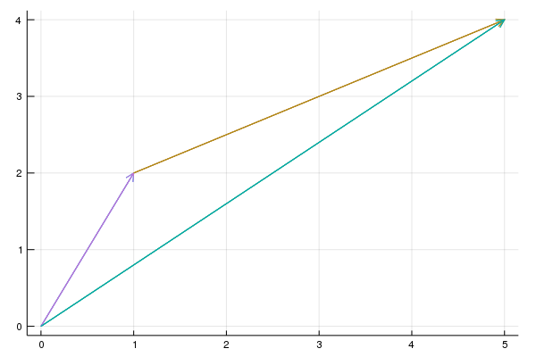

```julia
plot!()
arrow!(p, u)
arrow!(u, v)
arrow!(p, w)
```

The distinction between a point and a vector within `Julia` is only mental. We use the same storage type. Mathematically, we can **identify** a point and a vector, by considering the vector with its tail placed at the origin. In this case, the tip of the arrow is located at the point. But this is only an identification, though a useful one. It allows us to "add" a point and a vector (e.g., writing $P + \vec{v}$) by imagining the point as a vector anchored at the origin.

To see that a unit vector has the same "direction" as the vector, we might draw them with different widths:

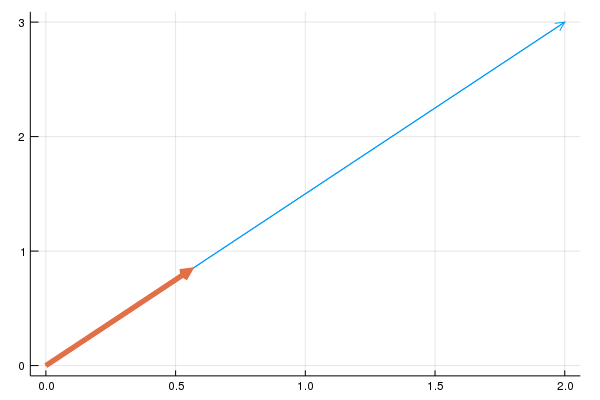

```julia
using LinearAlgebra
v = [2, 3]
u = v / norm(v)
p = [0, 0]
plot()
arrow!(p, v)
arrow!(p, u, linewidth=5)
```

The `norm` function is in the standard library, `LinearAlgebra`, which must be loaded first through the command `using LinearAlgebra`.

## The dot product

There is no concept of multiplying two vectors, or for that matter dividing two vectors. However, there are two operations between vectors that are somewhat similar to multiplication, these being the dot product and the cross product. Each has an algebraic definition, but their geometric properties are what motivate their usage. We begin by discussing the dot product.

The dot product between two vectors can be viewed algebraically in terms of the following product. If $\vec{v} = \langle v_1, v_2, \dots, v_n\rangle$ and $\vec{w} = \langle w_1, w_2, \dots, w_n\rangle$, then the *dot product* of $\vec{v}$ and $\vec{w}$ is defined by:

$$~ \vec{v} \cdot \vec{w} = v_1 w_1 + v_2 w_2 + \cdots + v_n w_n. ~$$

From this, we can see the relationship between the norm, or Euclidean length of a vector: $\vec{v} \cdot \vec{v} = \| \vec{v} \|^2$. We can also see that the dot product is commutative, that is $\vec{v} \cdot \vec{w} = \vec{w} \cdot \vec{v}$.

The dot product has an important geometrical interpolation. Two (non-parallel) vectors will lie in the same "plane", even in higher dimensions. Within this plane, there will be an angle between them within $[0, \pi]$. Call this angle $\theta$. (This means the angle between the two vectors is the same regardless of their order of consideration.) Then

$$~ \vec{v} \cdot \vec{w} = \|\vec{v}\| \|\vec{w}\| \cos(\theta). ~$$

If we denoted $\hat{v} = \vec{v} / \| \vec{v} \|$, the unit vector in the direction of $\vec{v}$, then by dividing, we see that $\cos(\theta) = \hat{v} \cdot \hat{w}$. That is the angle does not depend on the magnitude of the vectors involved.

The dot product is computed in `Julia` by the `dot` function, which is in the `LinearAlgebra` package of the standard library. This must be loaded (as above) before its use:

```julia
u = [1, 2]
v = [2, 1]
dot(u, v)
```

```
4
```

In `Julia`, the unicode operator entered by `\cdot[tab]` can also be used to mirror the math notation:

```julia
u ⋅ v   # u \cdot[tab] v
```

```
4
```

Continuing, to find the angle between $\vec{u}$ and $\vec{v}$, we might do this:

```julia
ctheta = dot(u/norm(u), v/norm(v))
acos(ctheta)
```

```
0.6435011087932845
```

The cosine of $\pi/2$ is $0$, so two vectors which are at right angles to each other will have a $0$ dot product:

```julia
u = [1, 2]
v = [-2, 1]
u ⋅ v
```

```
0
```

In two dimensions, we learn that a perpendicular line to a line with slope $m$ will have slope $-1/m$. From a 2-dimensional vector, say $\vec{u} = \langle u_1, u_2 \rangle$ the slope is $u_2/u_1$ so a perpendicular vector to $\vec{u}$ will be $\langle -u_2, u_1 \rangle$, as above. For higher dimensions, where the angle is harder to visualize, the dot product defines perpendicularness, or *orthogonality*.

For example, these two vectors are orthogonal, as their dot product is $0$, even though we can't readily visualize them:

```julia
u = [1,2,3,4,5]
v = [-30,4,3,2,1]
u ⋅ v
```

```
0
```

#### Projection

From right triangle trigonometry, we learn that $\cos(\theta) = \text{adjacent}/\text{hypotenuse}$. If we use a vector, $\vec{h}$ for the hypotenuse, and $\vec{a} = \langle 1, 0 \rangle$, we have this picture:

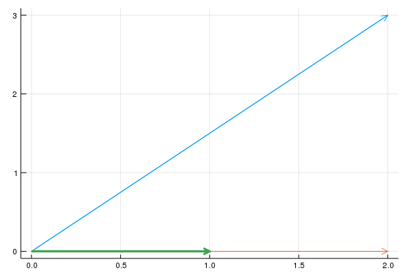

```julia
h = [2, 3]
a = [1, 0]  # unit vector
h_hat = h / norm(h)
theta = acos(h_hat ⋅ a)

plot()
arrow!([0,0], h)
arrow!([0,0], norm(h) * cos(theta) * a)
arrow!([0,0], a, linewidth=3)
```

We used vectors to find the angle made by `h`, and from there, using the length of the hypotenuse is `norm(h)`, we can identify the length of the adjacent side, it being the length of the hypotenuse times the cosine of $\theta$. Geometrically, we call the vector `norm(h) * cos(theta) * a` the *projection* of $\vec{h}$ onto $\vec{a}$, the word coming from the shadow $\vec{h}$ would cast on the direction of $\vec{a}$ were there light coming perpendicular to $\vec{a}$.

The projection can be made for any pair of vectors, and in any dimension $n > 1$. The projection of $\vec{u}$ on $\vec{v}$ would be a vector of length $\vec{u}$ (the hypotenuse) times the cosine of the angle in the direction of $\vec{v}$. In dot-product notation:

$$~ proj_{\vec{v}}(\vec{u}) = \| \vec{u} \| \frac{\vec{u}\cdot\vec{v}}{\|\vec{u}\|\|\vec{v}\|} \frac{\vec{v}}{\|\vec{v}\|}. ~$$

This can simplify. After cancelling, and expressing norms in terms of dot products, we have:

$$~ proj_{\vec{v}}(\vec{u}) = \frac{\vec{u} \cdot \vec{v}}{\vec{v} \cdot \vec{v}} \vec{v} = (\vec{u} \cdot \hat{v}) \hat{v}, ~$$

where $\hat{v}$ is the unit vector in the direction of $\vec{v}$.

##### Example

A pendulum, a bob on a string, swings back and forth due to the force of gravity. When the bob is displaced from rest by an angle $\theta$, then the tension force of the string on the bob, is directed along the string and has magnitude given by the *projection* of the force due to gravity.

A [force diagram](https://en.wikipedia.org/wiki/Free_body_diagram) is a useful visualization device of physics to illustrate the applied forces involved in a scenario. In this case the bob has two forces acting on it: a force due to tension in the string of unknown magnitude, but in the direction of the string; and a force due to gravity. The latter is in the downward direction and has magnitude $mg$, $g=9.8m/sec^2$ being the gravitational constant.

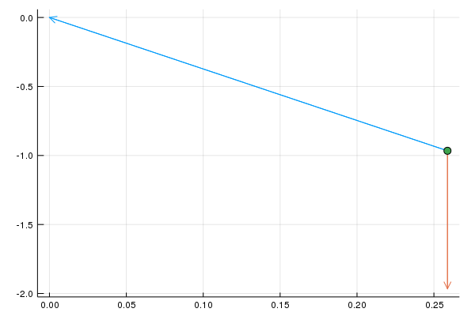

```julia
theta = pi/12
m, g = 1/9.8, 9.8

l = [-sin(theta), cos(theta)]
p = -l
Fg = [0, -m*g]
plot(legend=false)
arrow!(p, l)
arrow!(p, Fg)
scatter!(p[1:1], p[2:2], markersize=5)
```

The magnitude of the tension force is exactly that of the force of gravity projected onto $\vec{l}$, as the bob is not accelerating in that direction. The component of the gravity force in the perpendicular direction is the part of the gravitational force that causes acceleration in the pendulum. Here we find the projection onto $\vec{l}$ and visualize the two components of the gravitational force.

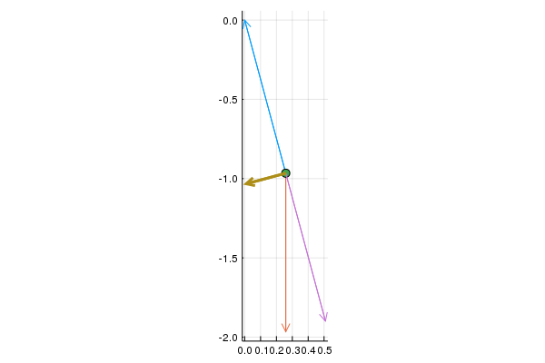

```julia
plot(legend=false, aspect_ratio=:equal)
arrow!(p, l)
arrow!(p, Fg)
scatter!(p[1:1], p[2:2], markersize=5)

proj = (Fg ⋅ l) / (l ⋅ l) * l   # force of gravity in direction of tension
porth = Fg - proj              # force of gravity perpendicular to tension

arrow!(p, proj)
arrow!(p, porth, linewidth=3)
```

##### Example

Starting with three vectors, we can create three orthogonal vectors using projection and subtraction. The creation of `porth` above is the pattern we will exploit.

Let's begin with three vectors in $R^3$:

```julia
u = [1, 2, 3]
v = [1, 1, 2]
w = [1, 2, 4]
```

```
3-element Array{Int64,1}:
 1
 2
 4
```

```julia
uvec(u) = u / norm(u)
projection(u, v) = (u ⋅ uvec(v)) * uvec(v)

vorth = u - projection(u, v)
worth = w - projection(w, u) - projection(w, vorth)
```

```
3-element Array{Float64,1}:
  0.2857142857142834
 -0.9285714285714255
  0.35714285714285765
```

```julia
u ⋅ vorth, u ⋅ worth, vorth ⋅ worth
```

```
(0.499999999999998, -0.49999999999999467, -0.6071428571428544)
```

This only works when the three vectors do not all lie in the same plane. In general, this is the beginnings of the Gram-Schmidt process for creating *orthogonal* vectors from a collection of vectors.

#### Algebraic properties

The dot product is similar to multiplication, but different as it is an operation defined between vectors of the same dimension. However, many algebraic properties carry over:

- commutative: $\vec{u} \cdot \vec{v} = \vec{v} \cdot \vec{u}$
- scalar multiplication: $(c\vec{u})\cdot\vec{v} = c(\vec{u}\cdot\vec{v})$.
- distributive $\vec{u} \cdot (\vec{v} + \vec{w}) = \vec{u} \cdot \vec{v} + \vec{u} \cdot \vec{w}$

The last two can be combined: $\vec{u}\cdot(s \vec{v} + t \vec{w}) = s(\vec{u}\cdot\vec{v}) + t (\vec{u}\cdot\vec{w})$.

But associative does not make sense, as $(\vec{u} \cdot \vec{v}) \cdot \vec{w}$ does not make sense as two dot products, as the result of the first is not a vector, but a scalar.

## Matrices

Algebraically, the dot product of two vectors–pair off by components, multiply these, then add– is a common operation. Take for example, the general equation of a line, or a plane:

$$~ ax + by = c, \quad ax + by + cz = d. ~$$

$$~ M = \left[ \begin{array}{} 3 & 4 & -5\\ 5 &-5 & 7\\ -3& 6 & 9 \end{array} \right],\quad \vec{x} = \langle x, y , z\rangle, \quad \text{ and } \vec{b} = \langle 10, 11, 12\rangle, ~$$

and the expression $M\vec{x} = \vec{b}b$. The matrix $M$ is a rectangular collection of numbers or expressions arranged in rows and columns with certain algebraic definitions. There are $m$ rows and $n$ columns in an $m\times n$ matrix. In this example $m=n=3$, and in such a case the matrix is called square. A vector, like $\vec{x}$ is usually identified with the $n \times 1$ matrix (a column vector). Were that done, the system of equations would be written $Mx=b$.

If we refer to a matrix $M$ by its components, a convention is to use $(M)_{ij}$ or $m_{ij}$ to denote the entry in the $i$th *row* and $j$th *column*. Following `Julia`'s syntax, we would use $m_{i:}$ to refer to *all* entries in the $i$th row, and $m_{:j}$ to denote *all* entries in the $j$ column.

Matrices, like vectors, have scalar multiplication defined for them. then scalar multiplication of a matrix $M$ by $c$ just multiplies each entry by $c$, so the new matrix would have components defined by $cm_{ij}$.

Matrices of the same size, like vectors, have addition defined for them. As with scalar multiplication, this defined component wise. So $A+B$ is the matrix with $ij$ entry $A_{ij} + B_{ij}$.

### Matrix multiplication

Matrix multiplication may be viewed as a collection of dot product operations. First, matrix multiplication is only defined between $A$ and $B$, as $AB$, if the size of $A$ is $m\times n$ and the size of $B$ is $n \times k$. That is the number of columns of $A$ must match the number of rows of $B$ for the left multiplication of $AB$ to be defined. It this is so, then we have the $ij$ entry of $AB$ is:

$$~ (AB)_{ij} = A_{i:} \cdot B_{:j}. ~$$

That is, if we view the $i$th row of $A$ and the $j$th column of B as a *vector*, then the $ij$ entry is the dot product.

This is why $M$ in the example above, has the coefficients for each equation in a row and not a column, and why $\vec{x}$ is thought of as a $n\times 1$ matrix (a column vector) and not as a row vector.

Matrix multiplication between $A$ and $B$ is not, in general, commutative. Not only may the sizes not permit $BA$ to be found when $AB$ may be, there is just no guarantee when the sizes match that the components will be the same.

Matrices have other operations defined on them. We mention two here:

- The tranpose of a matrix flips the difference between row and column, so the $ij$ entry of the transpose is the $ji$ entry of the matrix. This means the transpose will have size $n \times m$ when $M$ has size $m \times n$. Mathematically, the transpose is denoted $M^t$.
- The *determinant* of a *square* matrix is a number that can be used to characterize the matrix. The determinant may be computed different ways, but its [definition](https://en.wikipedia.org/wiki/Leibniz_formula_for_determinants) by the Leibniz formula is common. Two special cases are all we need. The $2\times 2$ case and the $3 \times 3$ case:

$$~ \left| \begin{array}{} a&b\\ c&d \end{array} \right| = ad - bc, \quad \left| \begin{array}{} a&b&c\\ d&e&f\\ g&h&i \end{array} \right| = a \left| \begin{array}{} e&f\\ h&i \end{array} \right| - b \left| \begin{array}{} d&f\\ g&i \end{array} \right| +c \left| \begin{array}{} d&g\\ e&h \end{array} \right|. ~$$

The $3\times 3$ case shows how determinants may be [computed recursively](https://en.wikipedia.org/wiki/Determinant#Definition), using "cofactor" expansion.

### Matrices in Julia

As mentioned previously, a matrix in `Julia` is defined component by component with `[]`. We separate row entries with spaces and columns with semicolons:

```julia
M = [3 4 -5; 5 -5 7; -3 6 9]
```

```
3×3 Array{Int64,2}:
  3   4  -5
  5  -5   7
 -3   6   9
```

Space is the separator, which means computing a component during definition (i.e., writing `2 + 3` in place of `5` is problematic, as no space can be used in the computation, lest it be parsed as a separator.

Vectors are defined similarly. As they are *column* vectors, we use a semicolon (or a comma) to separate:

```julia
b = [10, 11, 12]   # not b = [10 11 12], which would a row vector.
```

```
3-element Array{Int64,1}:
 10
 11
 12
```

In `Julia`, entries in a matrix (or a vector) are stored in a container with a type wide enough accomodate each entry. Here the type is SymPy's `Sym` type:

```julia
using SymPy
@vars x1 x2 x3
x = [x1, x2, x3]
```

\[ \left[ \begin{array}{r}x_{1}\\x_{2}\\x_{3}\end{array} \right] \]

Matrices may also be defined from blocks. This example shows how to make two column vectors into a matrix:

```julia
u = [10, 11, 12]
v = [13, 14, 15]
[u v]   # horizontally combine
```

```
3×2 Array{Int64,2}:
 10  13
 11  14
 12  15
```

Vertically combining the two will stack themL

```julia
[u; v]
```

```
6-element Array{Int64,1}:
 10
 11
 12
 13
 14
 15
```

Scalar multiplication will just work as expected:

```julia
2 * M
```

```
3×3 Array{Int64,2}:
  6    8  -10
 10  -10   14
 -6   12   18
```

Matrix addition is also straightforward:

```julia
M + M
```

```
3×3 Array{Int64,2}:
  6    8  -10
 10  -10   14
 -6   12   18
```

Matrix addition expects matrices of the same size. An error will otherwise be thrown. However, if addition is *broadcasted* then the sizes need only be commensurate. For example, this will add `1` to each entry of `M`:

```julia
M .+ 1
```

```
3×3 Array{Int64,2}:
  4   5  -4
  6  -4   8
 -2   7  10
```

Matrix multiplication is defined by `*`:

```julia
M * M
```

```
3×3 Array{Int64,2}:
  44  -38  -32
 -31   87    3
  -6   12  138
```

We can then see how the system of equations is represented with matrices:

```julia
M * x - b
```

\[ \left[ \begin{array}{r}3 x_{1} + 4 x_{2} - 5 x_{3} - 10\\5 x_{1} - 5 x_{2} + 7 x_{3} - 11\\- 3 x_{1} + 6 x_{2} + 9 x_{3} - 12\end{array} \right] \]

Here we use `SymPy` to verify the above:

```julia
A = [symbols("A$i$j", real=true) for i in 1:3, j in 1:2]
B = [symbols("B$i$j", real=true) for i in 1:2, j in 1:2]
```

\[\left[ \begin{array}{rr}B_{11}&B_{12}\\B_{21}&B_{22}\end{array}\right]\]

The matrix product has the expect size: the number of rows of `A` (3) by the number of columns of `B` (2):

```julia
A*B
```

\[\left[ \begin{array}{rr}A_{11} B_{11} + A_{12} B_{21}&A_{11} B_{12} + A_{12} B_{22}\\A_{21} B_{11} + A_{22} B_{21}&A_{21} B_{12} + A_{22} B_{22}\\A_{31} B_{11} + A_{32} B_{21}&A_{31} B_{12} + A_{32} B_{22}\end{array}\right]\]

This confirms how each entry (`(A*B)[i,j]`) is from a dot product (`A[i,:] ⋅ B[:,j]`):

```julia
[ (A*B)[i,j] == A[i,:] ⋅ B[:,j] for i in 1:3, j in 1:2]
```

```
3×2 Array{Bool,2}:
 true  true
 true  true
 true  true
```

When the multiplication is broadcasted though, with `.*`, the operation will be component wise:

```julia
M .* M   # component wise
```

```
3×3 Array{Int64,2}:
  9  16  25
 25  25  49
  9  36  81
```

The transpose of a matrix is found through `transpose` which doesn't create a new object, but rather an object which knows to switch indices when referenced:

```julia
transpose(M)
```

```
3×3 Transpose{Int64,Array{Int64,2}}:
  3   5  -3
  4  -5   6
 -5   7   9
```

For matrices with *real* numbers, the transpose can be performed with the postfix operation `'`:

```julia
M'
```

```
3×3 Adjoint{Int64,Array{Int64,2}}:
  3   5  -3
  4  -5   6
 -5   7   9
```

(However, this is not true for matrices with complex numbers as `'` is the "adjoint," that is, the transpose of the matrix *after* taking complex conjugates.)

With `u` and `v`, vectors from above, we have:

```julia
[u' v']   # [u v] was a 3 × 2 matrix, above
```

```
1×6 Adjoint{Int64,Array{Int64,1}}:
 10  11  12  13  14  15
```

and

```julia
[u'; v']
```

```
2×3 Array{Int64,2}:
 10  11  12
 13  14  15
```

The determinant is found through `det` provided by the built-in `LinearAlgebra` package:

```julia
using LinearAlgebra
det(M)
```

```
-600.0
```

The dot product and matrix multiplication are related, and mathematically identified through the relation: $\vec{u} \cdot \vec{v} = u^t v$, where the right hand side identifies $\vec{u}$ and $\vec{v}$ with a $n\times 1$ column matrix, and $u^t$ is the transpose, or a $1\times n$ row matrix. However, mathematically the left side is a scalar, but the right side a $1\times 1$ matrix. While distinct, the two are identified as the same. This is similar to the useful identification of a point and a vector. Within `Julia`, these identifications are context dependent. `Julia` stores vectors as 1-dimensional arrays, transposes as $1$-dimensional objects, and matrices as $2$-dimensional arrays. The product of a transpose and a vector is a scalar:

```julia
u, v = [1,1,2], [3,5,8]
u' * v   # a scalar
```

```
24
```

But if we make `u` a matrix (here by "`reshape`ing" in a matrix with $1$ row and $3$ columns), we will get a matrix (actually a vector) in return:

```julia
reshape(u,(1,3)) * v
```

```
1-element Array{Int64,1}:
 24
```

## Cross product

In three dimensions, there is a another operation between vectors that is similar to multiplication, though we will see with many differences.

Let $\vec{u}$ and $\vec{v}$ be two 3-dimensional vectors, then the *cross* product, $\vec{u} \times \vec{v}$, is defined as a vector with length:

$$~ \| \vec{u} \times \vec{v} \| = \| \vec{u} \| \| \vec{v} \| \sin(\theta), ~$$

with $\theta$ being the angle in $[0, \pi]$ between $\vec{u}$ and $\vec{v}$. Consequently, $\sin(\theta) \geq 0$.

The direction of the cross product is such that it is *orthogonal* to *both* $\vec{u}$ and $\vec{v}$. To identify this, the [right-hand rule](https://en.wikipedia.org/wiki/Cross_product#Definition) is used. This rule points the right hand fingers in the direction of $\vec{u}$ and curls them towards $\vec{v}$ (so that the angle between the two vectors is in $[0, \pi]$). The thumb will point in the direction. Call this direction $\hat{n}$, a normal unit vector. Then the cross product can be defined by:

$$~ \vec{u} \times \vec{v} = \| \vec{u} \| \| \vec{v} \| \sin(\theta) \hat{n}. ~$$

The right-hand rule is also useful to understand how standard household screws will behave when twisted with a screwdriver. If the right hand fingers curl in the direction of the twisting screwdriver, then the screw will go in or out following the direction given by the orientation of the thumb.

The right-hand rule depends on the order of consideration of the vectors. If they are reversed, the opposite direction is determined. A consequence is that the cross product is **anti**-commutative, unlike multiplication:

$$~ \vec{u} \times \vec{v} = - \vec{v} \times \vec{u}. ~$$

Mathematically, the definition in terms of its components is a bit involved:

$$~ \vec{u} \times \vec{v} = \langle u_2 v_3 - u_3 v_2, u_3 v_1 - u_1 v_3, u_1 v_2 - u_2 v_1 \rangle. ~$$

There is a matrix notation that can simplify this computation. If we *formally* define $\vec{i}$, $\vec{j}$, and $\vec{k}$ to represent unit vectors in the $x$, $y$, and $z$ direction, then a vector $\langle u_1, u_2, u_3 \rangle$ could be written $u_1\vec{i} + u_2\vec{j} + u_3\vec{k}$. With this the cross product of $\vec{u}$ and $\vec{v}$ is the vector associated with the *determinant* of the matrix

$$~ \left[ \begin{array}{} \vec{i} & \vec{j} & \vec{k}\\ u_1 & u_2 & u_3\\ v_1 & v_2 & v_3 \end{array} \right]. ~$$

From the $\sin(\theta)$ term in the definition, we see that $\vec{u}\times\vec{u}=0$. In fact, the cross product is $0$ only if the two vectors involved are parallel or there is a zero vector.

In `Julia`, the `cross` function from the `LinearAlgebra` package (part of the standard library) implements the cross product. There is also the *infix* unicode operator `\times[tab]` that can be used for similarity to traditional mathematical syntax. For example:

```julia
a = [1, 2, 3]
b = [4, 2, 1]
cross(a, b)
```

```
3-element Array{Int64,1}:
 -4
 11
 -6
```

Or

```julia
a × b
```

```
3-element Array{Int64,1}:
 -4
 11
 -6
```

We can see the cross product is anti-commutative by comparing the last answer with:

```julia
b × a
```

```
3-element Array{Int64,1}:
   4
 -11
   6
```

Using vectors of size different than $n=3$ produces a dimension mismatch error:

```julia
[1, 2] × [3, 4]
```

```
DimensionMismatch("cross product is only defined for vectors of length 3")
```

Let's see that the matrix definition will be identical (after identifications) to `cross`:

```julia
using SymPy, LinearAlgebra
@vars i j k
M = [i j k; 3 4 5; 3 6 7]
det(M) |> simplify
```

\begin{equation*}- 2 i - 6 j + 6 k\end{equation*}

Compare with

```julia
M[2,:] × M[3,:]
```

\[ \left[ \begin{array}{r}-2\\-6\\6\end{array} \right] \]

Consider this extended picture involving two vectors $\vec{u}$ and $\vec{v}$ drawn in two dimensions:

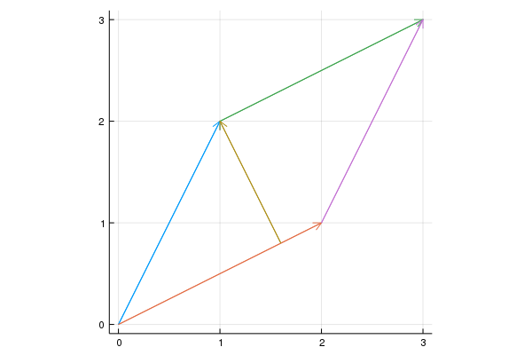

```julia
u = [1, 2]
v = [2, 1]
p = [0,0]

plot(aspect_ratio=:equal)
arrow!(p, u)
arrow!(p, v)
arrow!(u, v)
arrow!(v, u)

puv = (u ⋅ v) / (v ⋅ v) * v
porth = u - puv
arrow!(puv, porth)
```

The enclosed shape is a parallelogram. To this we added the projection of $\vec{u}$ onto $\vec{v}$ (`puv`) and then the *orthogonal* part (`porth`).

The *area* of a parallelogram is the length of one side times the perpendicular height. The perpendicular height could be found from `norm(porth)`, so the area is:

```julia
norm(v) * norm(porth)
```

```
3.0
```

However, from trigonometry we have the height would also be the norm of $\vec{u}$ times $\sin(\theta)$, a value that is given through the length of the cross product of $\vec{u}$ and $\hat{v}$, the unit vector, were these vectors viewed as 3 dimensional by adding a $0$ third component. In formulas, this is also the case:

$$~ \text{area of the parallelogram} = \| \vec{u} \times \hat{v} \| \| \vec{v} \| = \| \vec{u} \times \vec{v} \|. ~$$

We have, for our figure, after extending `u` and `v` to be three dimensional the area of the parallelogram:

```julia
u = [1, 2, 0]
v = [2, 1, 0]
norm(u × v)
```

```
3.0
```

This analysis can be extended to the case of 3 vectors, which–when not co-planar–will form a *parallelepiped*.

```julia
plotly()
u,v,w = [1,2,3], [2,1,0], [1,1,2]
plot()
p = [0,0,0]

plot(legend=false)
arrow!(p, u); arrow!(p, v); arrow!(p, w)
arrow!(u, v); arrow!(u, w)
arrow!(v, u); arrow!(v, w)
arrow!(w, u); arrow!(w, v)
arrow!(u+v, w); arrow!(u+w, v); arrow!(v+w,u)
```

[output not shown]

The volume of a parallelepiped is the area of a base parallelogram times the height of a perpendicular. If $\vec{u}$ and $\vec{v}$ form the base parallelogram, then the perpendicular will have height $\|\vec{w}\| \cos(\theta)$ where the angle is the one made by $\vec{w}$ with the normal, $\vec{n}$. Since $\vec{u} \times \vec{v} = \| \vec{u} \times \vec{v}\| \hat{n} = \hat{n}$ times the area of the base parallelogram, we have if we dot this answer with $\vec{w}$:

$$~ (\vec{u} \times \vec{v}) \cdot \vec{w} = \|\vec{u} \times \vec{v}\| (\vec{n} \cdot \vec{w}) = \|\vec{u} \times \vec{v}\| \| \vec{w}\| \cos(\theta), ~$$

that is, the area of the parallelepiped. Wait, what about $(\vec{v}\times\vec{u})\cdot\vec{w}$? That will have an opposite sign. Yes, in the above, there is an assumption that $\vec{n}$ and $\vec{w}$ have a an angle between them within $[0, \pi/2]$, otherwise an absolute value must be used, as volume is non-negative.

#### Algebraic properties

The cross product has many properties, some different from regular multiplication:

- scalar multiplication: $(c\vec{u})\times\vec{v} = c(\vec{u}\times\vec{v})$
- distributive over addition: $\vec{u} \times (\vec{v} + \vec{w}) = \vec{u}\times\vec{v} + \vec{u}\times\vec{w}$.
- *anti*-commutative: $\vec{u} \times \vec{v} = - \vec{v} \times \vec{u}$
- *not* associative: that is there is no guarantee that $(\vec{u}\times\vec{v})\times\vec{w}$ will be equivalent to $\vec{u}\times(\vec{v}\times\vec{w})$.
- The triple cross product $(\vec{u}\times\vec{v}) \times \vec{w}$ must be orthogonal to $\vec{u}\times\vec{v}$ so lies in a plane with this as a normal vector. But, $\vec{u}$ and $\vec{v}$ will generate this plane, so it should be possible to express this triple product in terms of a sum involving $\vec{u}$ and $\vec{v}$ and indeed:

$$~ (\vec{u}\times\vec{b})\times\vec{w} = (\vec{u}\cdot\vec{w})\vec{v} - (\vec{v}\cdot\vec{w})\vec{u}. ~$$

The following shows the algebraic properties stated above hold for symbolic vectors. First the linearity of the dot product:

```julia
using SymPy
@vars s t u1 u2 u3 v1 v2 v3 w1 w2 w3 real=true
u = [u1, u2, u3]
v = [v1, v2, v3]
w = [w1, w2, w3]

u ⋅ (s*v + t*w) - (s*(u⋅v) + t*(u⋅w)) |> simplify
```

\begin{equation*}0\end{equation*}

This shows the dot product is commutative:

```julia
(u ⋅ v) - (v ⋅ u) |> simplify
```

\begin{equation*}0\end{equation*}

This shows the linearity of the cross product over scalar multiplication and vector addition:

```julia
u × (s*v + t*w) - (s*(u×v) + t*(u×w)) .|> simplify
```

\[ \left[ \begin{array}{r}0\\0\\0\end{array} \right] \]

(We use `.|>` to broadcast `simplify` over each component.)

The cross product is anti-commutative:

```julia
u × v + v × u .|> simplify
```

\[ \left[ \begin{array}{r}0\\0\\0\end{array} \right] \]

but not associative:

```julia
u × (v × w) - (u × v) × w .|> simplify
```

\[ \left[ \begin{array}{r}u_{1} v_{2} w_{2} + u_{1} v_{3} w_{3} - u_{2} v_{2} w_{1} - u_{3} v_{3} w_{1}\\- u_{1} v_{1} w_{2} + u_{2} v_{1} w_{1} + u_{2} v_{3} w_{3} - u_{3} v_{3} w_{2}\\- u_{1} v_{1} w_{3} - u_{2} v_{2} w_{3} + u_{3} v_{1} w_{1} + u_{3} v_{2} w_{2}\end{array} \right] \]

Finally we verify the decomposition of the triple cross product:

```julia
(u × v) × w - ( (u ⋅ w) * v - (v ⋅ w) * u) .|> simplify
```

\[ \left[ \begin{array}{r}0\\0\\0\end{array} \right] \]

This table shows common usages of the symbols for various multiplication types: `*`, $\cdot$, and $\times$:

| Symbol | inputs | output | type |
| --- | --- | --- | --- |
| `*` | scalar, scalar | scalar | regular multiplication |
| `*` | scalar, vector | vector | scalar multiplication |
| `*` | vector, vector | *undefined* |  |
| $\cdot$ | scalar, scalar | scalar | regular multiplication |
| $\cdot$ | scalar, vector | vector | scalar multiplication |
| $\cdot$ | vector, vector | scalar | dot product |
| $\times$ | scalar, scalar | scalar | regular multiplication |
| $\times$ | scalar, vector | undefined |  |
| $\times$ | vector, vector | vector | cross product |

##### Example: lines and planes

A line in two dimensions satisfies the equation $ax + by = c$. Suppose $a$ and $b$ are non-zero. This can be represented in vector form, as the collection of all points associated to the vectors: $p + t \vec{v}$ where $p$ is a point on the line, say $(0,c/b)$, and v is the vector $\langle b, -a \rangle$. We can verify, this for values of `t` as follows:

```julia
@vars a b c x y t

eq = c - (a*x + b*y)

p = [0, c/b]
v = [-b, a]
li = p + t * v

eq(x=>li[1], y=>li[2]) |> simplify
```

\begin{equation*}0\end{equation*}

Let $\vec{n} = \langle a , b \rangle$, taken from the coefficients in the equation. We can see directly that $\vec{n}$ is orthogonal to $\vec{v}$. The line may then be seen as the collection of all vectors that are orthogonal to $\vec{n}$ that have their tail at the point $p$.

In three dimensions, the equation of a plane is $ax + by + cz = d$. Suppose, $a$, $b$, and $c$ are non-zero, for simplicity. Setting $\vec{n} = \langle a,b,c\rangle$ by comparison, it can be seen that plane is identified with the set of all vectors orthogonal to $\vec{n}$ that are anchored at $p$.

First, let $p = (0, 0, d/c)$ be a point on the plane. We find two vectors $u = \langle -b, a, 0 \rangle$ and $v = \langle 0, c, -b \rangle$. Then any point on the plane may be identified with the vector $p + s\vec{u} + t\vec{v}$. We can verify this algebraically through:

```julia
@vars d z s

eq = d - (a*x + b*y + c * z)

p = [0, 0, d/c]
u, v = [-b, a, 0], [0, c, -b]
pl = p + t * u + s * v

subs(eq, x=>pl[1], y=>pl[2], z=>pl[3]) |> simplify
```

\begin{equation*}0\end{equation*}

The above viewpoint can be reversed:

> a plane is determined by two (non-parallel) vectors and a point.

The parameterized version of the plane would be $p + t \vec{u} + s \vec{v}$, as used above.

```julia
u = [1,2,3]
v = [2,3,1]
n = u × v
p = [0,0,1]

plot(legend=false)

arrow!(p, u)
arrow!(p, v)
arrow!(p + u, v)
arrow!(p + v, u)
arrow!(p, n)

s, t = 1/2, 1/4
arrow!(p, s*u + t*v)
```

[output not shown]

So if $\vec{n} \cdot p = d$ (identifying the point $p$ with a vector so the dot product is defined), we will have for any vector $\vec{v} = \langle x, y, z \rangle = s \vec{u} + t \vec{v}$ that

$$~ \vec{n} \cdot (p + s\vec{u} + t \vec{v}) = \vec{n} \cdot p + \vec{n} \cdot (s \vec{u} + t \vec{v}) = d + 0 = d, ~$$

But if $\vec{n} = \langle a, b, c \rangle$, then this says $d = ax + by + cz$, so from $\vec{n}$ and $p$ the equation of the plane is given.

In summary:

| Object | Equation | vector equation |
| --- | --- | --- |
| Line | $ax + by = c$ | line: $p + t\vec{u}$ |
| Plane | $ax + by + cz = d$ | plane: $p + s\vec{u} + t\vec{v}$ |

##### Example

You are given that the vectors $\vec{u} =\langle 6, 3, 1 \rangle$ and $\vec{v} = \langle 3, 2, 1 \rangle$ describe a plane through the point $p=[1,1,2]$. Find the equation of the plane.

The key is to find the normal vector to the plane, $\vec{n} = \vec{u} \times \vec{v}$:

```julia
u, v, p = [6,3,1], [3,2,1], [1,1,2]
n = u × v
a, b, c = n
d = n ⋅ p
"equation of plane: $a x + $b y + $c z = $d"
```

equation of plane: 1 x + -3 y + 3 z = 4

## Questions

###### Question

Let `u=[1,2,3]`, `v=[4,3,2]`, and `w=[5,2,1]`.

Find `u ⋅ v`:

Are `v` and `w` orthogonal?

Yes

No

Find the angle between `u` and `w`:

Find `u × v`:

`[-5, 10, -5]`

`[-1, 6, -7]`

`[-4, 14, -8]`

Find the area of the parallelogram formed by `v` and `w`

Find the volume of the parallelepiped formed by `u`, `v`, and `w`:

###### Question

The dot product of two vectors may be described in words: pair off the corresponding values, multiply them, then add. In `Julia` the `zip` command will pair off two iterable objects, like vectors, so it seems like this command: `sum(prod.(zip(u,v)))` will find a dot product. Investigate if it is does or doesn't by testing the following command and comparing to the dot product:

```julia
u,v = [1,2,3], [5,4,2]
sum(prod.(zip(u,v)))
```

Does this return the same answer:

Yes

No

What does command `zip(u,v)` return?

A vector of values `[(1, 5), (2, 4), (3, 2)]`

An object of type `Base.Iterators.Zip` that is only realized when used

What does `prod.(zip(u,v))` return?

An object of type `Base.Iterators.Zip` that when realized will produce a vector of values

A vector of values `[5, 8, 6]`

###### Question

Let $\vec{u}$ and $\vec{v}$ be 3-dimensional **unit** vectors. What is the value of

$$~ (\vec{u} \times \vec{v}) \cdot (\vec{u} \times \vec{v}) + (\vec{u} \cdot \vec{v})^2? ~$$

Can't say in general

$0$

$1$

###### Question

Consider the projection of $\langle 1, 2, 3\rangle$ on $\langle 3, 2, 1\rangle$. What is its length?

###### Question

Let $\vec{u} = \langle 1, 2, 3 \rangle$ and $\vec{v} = \langle 3, 2, 1 \rangle$. Describe the plane created by these two non-parallel vectors going through the origin.

$x + 2y + z = 0$

$x + 2y + 3z = 6$

$-4x + 8y - 4z = 0$

###### Question

A plane $P_1$ is *orthogonal* to $\vec{n}_1$, a plane $P_2$ is *orthogonal* to $\vec{n}_2$. Explain why vector $\vec{v} = \vec{n}_1 \times \vec{n}_2$ is parallel to the *intersection* of $P_1$ and $P_2$.

$\vec{v}$

is in plane $P_1$, as it is orthogonal to $\vec{n}_1$ and $P_2$ as it is orthogonal to $\vec{n}_2$, hence it is parallel to both planes.

$\vec{n}_1$

and $\vec{n_2}$ are unit vectors, so the cross product gives the projection, which must be orthogonal to each vector, hence in the intersection

###### Question

(From Strang). For an (analog) clock draw vectors from the center out to each of the 12 hours marked on the clock. What is the vector sum of these 12 vectors?

$\vec{0}$

$\langle 12, 12 \rangle$

$12 \langle 1, 0 \rangle$

$\langle -1, 0 \rangle$

$\langle 1, 0 \rangle$

$\langle 11, 11 \rangle$

###### Question

Let $\vec{u}$ and $\vec{v}$ be unit vectors. Let $\vec{w} = \vec{u} + \vec{v}$. Then $\vec{u} \cdot \vec{w} = \vec{v} \cdot \vec{w}$. What is the value?

$1 + \vec{u}\cdot\vec{v}$

$\vec{u} + \vec{v}$

$\vec{u}\cdot\vec{v} + \vec{v}\cdot \vec{v}$

As the two are equal, which interpretation is true?

$\vec{w}$

must also be a unit vector

The angle they make with $\vec{w}$ is the same

the two are orthogonal

###### Question

Suppose $\| \vec{u} + \vec{v} \|^2 = \|\vec{u}\|^2 + \|\vec{v}\|^2$. What is $\vec{u}\cdot\vec{v}$?

We have $(\vec{u} + \vec{v})\cdot(\vec{u} + \vec{v}) = \vec{u}\cdot \vec{u} + 2 \vec{u}\cdot\vec{v} + \vec{v}\cdot\vec{v}$. From this, we can infer that:

$\vec{u}\cdot\vec{v} = 0$

$\vec{u}\cdot\vec{v} = 2$

$\vec{u}\cdot\vec{v} = -(\vec{u}\cdot\vec{u} \vec{v}\cdot\vec{v})$

###### Question

Give a geometric reason for this identity:

$$~ \vec{u} \cdot (\vec{v} \times \vec{w}) = \vec{v} \cdot (\vec{w} \times \vec{u}) = \vec{w} \cdot (\vec{u} \times \vec{v}) ~$$

###### Question

Show the Jacobi relationship holds for 3 randomly chosen vectors:

$$~ \vec{a}\times(\vec{b}\times\vec{c})+ \vec{b}\times(\vec{c}\times\vec{a})+ \vec{c}\times(\vec{a}\times\vec{b}) ~$$